# US Congressional Social Media

### How is US partisanship exhibited in social media?

The second question this paper seeks to answer is how American partisanship is exhibited in social media. First, the presence of partisanship in social media usage will need to be proven. This alleged partisanship will then need to be identified, validated, and quantified to form a full analysis of its presence and effect in social media. These analyses were done using data for frequently used terms by Congress members on Twitter and Facebook. These sites claim to be reflective of our society, but can they be used to analyse US government opinions as well?

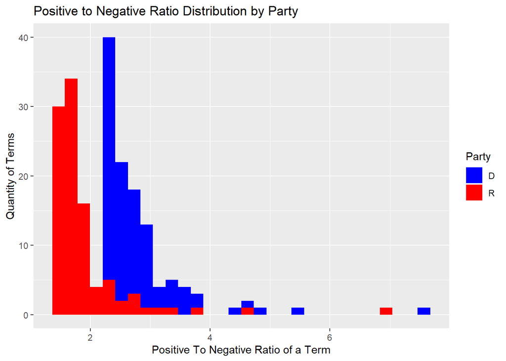

While the last analysis displayed that there is partisanship present in social media, this analysis can get deeper and pinpoint this partisanship. Using the same terms data as above, a new variable to measure partisanship was created. For each term this “Party Difference” variable represents a difference in term usage by political party. The top ten terms for each party with the largest party difference variable value were aggregated with their color representing the party that used the term most frequently. These top terms were arranged based on their party difference and are represented below as a graph and as a table.

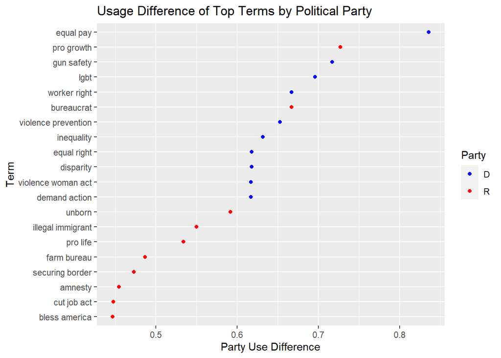

```
##           Term Party PartyDifference Proportion of Party
## 1    equal pay     D           0.836               0.964
## 2   pro growth     R           0.727               0.851
## 3   gun safety     D           0.717               0.879
## 4         lgbt     D           0.696               0.879
## 5   bureaucrat     R           0.667               0.851
## 6 worker right     D           0.667               0.855
```

The graph and table above show a representation of the terms that have the largest party difference. Democrats tended to have larger values than the Republican used terms, meaning that as a party they tend to use more of the same terminology in social media. This could indicate better party cohesion for Democrats due to the large proportion of members that chose to use the same terms. It is also important to note that this high Party Difference value means that a large number of the term’s own party used it in social media, as well as a small number of the opposing party using it. Therefore, by having a larger gap in party usage, this variable quantifies and identifies how partisan a term is in social media. The terms with the six largest party difference values were “equal pay”, “pro growth”, “gun safety”, “lgbt”, “bureaucrat”, and “worker right”. As discussed before, that would make these specific terms hyper-partisan terms due to them being used near exclusively by one party. To verify this, the most partisan term the data found was “equal pay”. This is a large platform issue for Democrats and the Congressional lawmakers have drafted a lot of legislation around the issue, whereas the Republican members have not, therefore validating the results. Similarly for the other terms, these all do tend to be issues that America is deeply divided on by political party. The data then can show this deep division and pinpoint key areas through social media usage by Congress members.

In the question of US partisanship in social media, this Congressional dataset was able to offer many insights. By looking into the difference in effects of the terms each party used, the data show that it is possible to view partisanship in American politics through the social media activities of the legislative branch members. The analysis was then able to narrow down and even quantify this partisanship by term to single out key divisive issues in the American political landscape. Overall, it is apparent that the Democratically used terms had more of an effect when used on social media. It is also evident that Democrats tend to use more partisan terms than Republicans. This data and analysis shows that US partisanship can be shown, identified, and quantified exclusively through the social media usage of Congress members.

# Misc

Datasets: https://www.pewresearch.org/internet/2020/07/16/congress-soars-to-new-heights-on-social-media/

Credit: This project is based off of a final project for STOR 320 Data Science. The figures for Terms Used Over Time by Party and Foreign Policy Terms Used Over Time by Party were reproduced from the group project, however all analysis and other figures were produced by myself.